# 2016 Presidential Contributions

# Final Visualizations

The summary for each candidate by mean, median, and sum of contributions, faceted by whether it was the primary or general elections was definitely a useful plot– reproduced below:

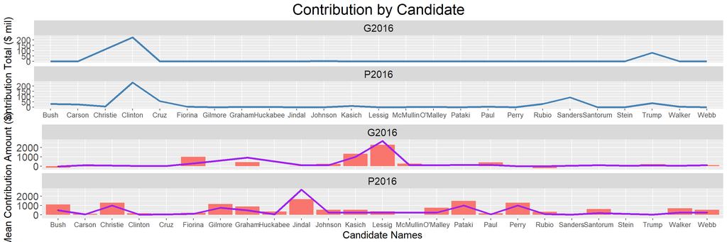

```r
p1<-ggplot(aes(x=names,y=contb_receipt_amt,group=1),
       data=plotCont)+
  geom_bar(aes(fill='red'),stat="summary",fun.y=mean)+ #bar plot for mean of contbributions by candidate
  facet_wrap(~election_tp,nrow = 2)+                   #split into the primary and general elections.
  geom_point(alpha=.5,size=.75,stat="summary",fun.y=median)+
  geom_line(color='purple',stat="summary",fun.y=median,size=1.25)+ #line plot for median contributions.
  labs(x="Candidate Names",y="Mean Contribution Amount ($)")+
  theme(axis.text.x = element_text(size=10),
        axis.text.y = element_text(size=15),
        axis.title = element_text(size=15),
        strip.text = element_text(size=15))+
  guides(fill=FALSE)
p2<-ggplot(aes(x=names,y=contb_receipt_amt/1000000,group=1),
           data=plotCont)+
  ylab("Contribution Total ($ mil)")+          #line plot for sum of contributions by candidate split by primary and
  ggtitle("Contribution by Candidate")+        #general elections.
  geom_line(size=1.25,color='steelblue',stat="summary",fun.y=sum)+
  theme(plot.title = element_text(hjust=.5,size=22),axis.title.x=element_blank(),
        axis.text.x = element_text(size=10),
        axis.text.y = element_text(size=13),
        axis.title=element_text(size=15),
        strip.text = element_text(size=15))+
  facet_wrap(~election_tp,nrow=2)+
    guides(fill=FALSE)
grid.arrange(p2,p1)
```

The next plot I chose, as it is the next level of abstraction, shows the differences across parties.

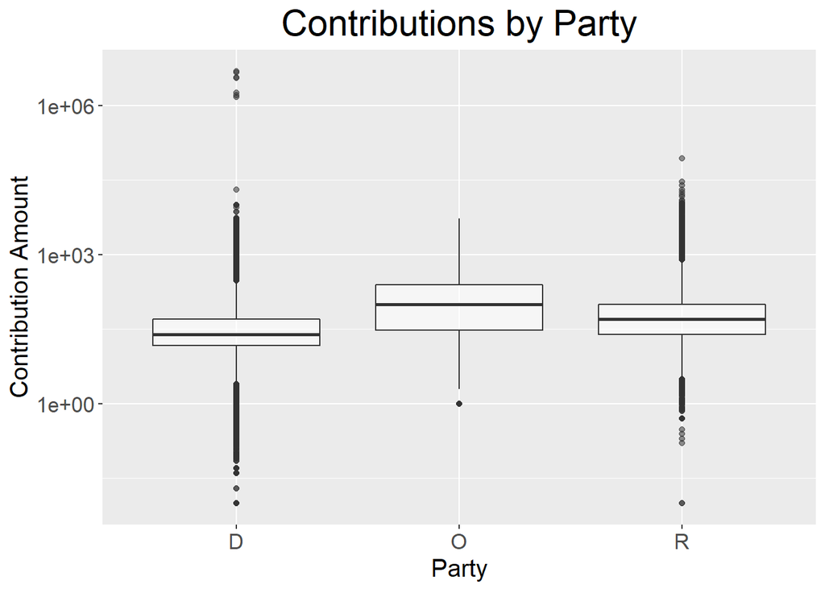

```r
ggplot(aes(x=party,y=contb_receipt_amt),data=plotCont)+
  geom_boxplot(aes(alpha=.1))+
  xlab("Party")+ylab("Contribution Amount")+ggtitle("Contributions by Party")+
  theme(plot.title = element_text(hjust=.5,size=22),
        axis.title = element_text(size=15),
        axis.text = element_text(size=13),
        legend.position = "none")+
  #coord_cartesian(ylim=c(quantile(Contributions[Contributions$party=="R",]$contb_receipt_amt,probs=.25),
  #                       quantile(Contributions[Contributions$party=="R",]$contb_receipt_amt,probs=.95)))+
  scale_y_log10()
```

```r
#plotting boxplots for both contributions by gender and party with the 25th
#and 95th percentiles used to give a better picture of the plots.
```

Finally, the map visualization, for the main candidates is a worthwhile display of the data and the differences across these candidates:

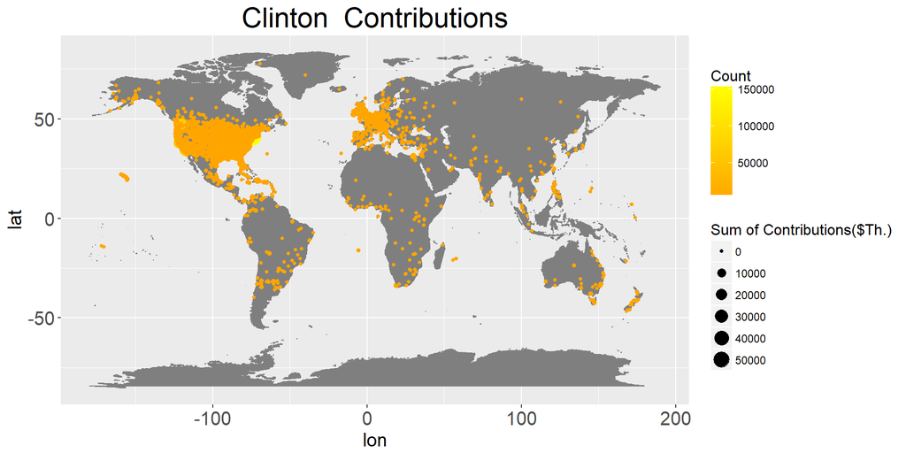

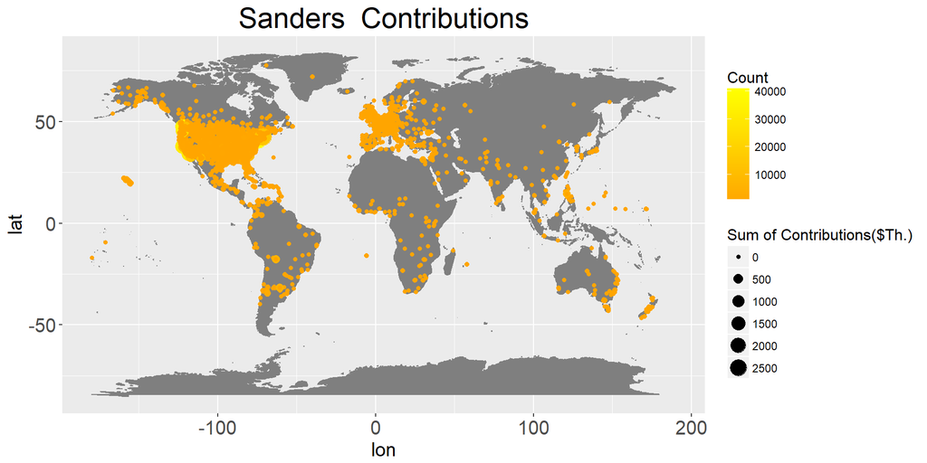

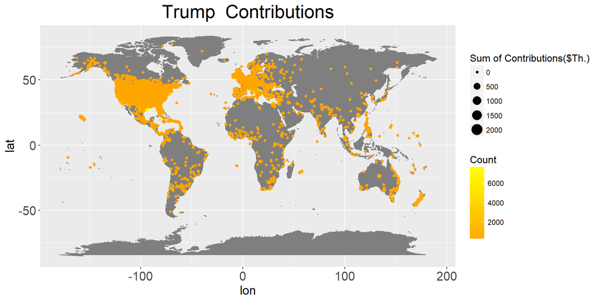

```r
#Redoing the maps with size and color affected by sum and count.
for (i in c("Clinton","Sanders","Trump")){
  print(ggplot(aes(x=lon,y=lat),data=get(i))+borders("world",colour="gray50",
                                                     fill="gray50")+
    geom_point(aes(col=get(i)$n,size=get(i)$sum_of_cont/1000))+
      scale_color_gradient2(low="red",mid="orange",high="yellow")+
    ggtitle(paste(i," Contributions"))+theme(axis.title =
                                               element_text(size=15),
                     axis.text = element_text(size=15),
                     plot.title = element_text(hjust=.5,size=22),
                     legend.title = element_text(size=12)
    )+labs(color="Count",size="Sum of Contributions($Th.)")
    )
    }
```

All three candidates seem to have similar locations contributing to them. Sanders garners donors from more locations than Clinton, and Trump garners even more locations than either!! But, both Sanders and Clinton seem to have areas with more-so higher contributions, though obviously less populated.

Results:

One struggle I had while creating this was figuring out to display the city data, especially because of the large number of observations. In terms of coding this was solved by parsing the data rather than iterating over it, and visually solved by mapping mean, count and sum values. On the other hand, I also struggled with the data for occupation, which I feel is really valuable data, but much more-so difficult to make a visualization for. A possible visualization could just be a table, much like the ones created for cities, that contains the top ten occupations by candidate!

For improvements and further research, I would suggest attemping to do this for local elections, and then determining whether contributions actually affect winning rates (for Which the data here suggests they do not).